# Lab_Recurrent_4_final_version

```python
import os
from torchvision import transforms
from torch.utils.data import DataLoader, Dataset, TensorDataset
import torch.nn as nn
from PIL import Image, ImageOps
import torch
import pdb
import numpy as np
import yaml
from tqdm import tqdm
import sys
sys.path.append('..')
from template import utils
```

```python
utils.set_random_seeds(False)
torch.use_deterministic_algorithms(False)
```

```python
# Define the subjects for each split
# In the past, there existed validation and test subjects, but the method changed a bit
train_subjects = [11, 12, 13, 14, 15, 16, 21, 23, 3 ,5 ] #3, 6, 7, 1, 2, 4, 8]
# Define the background variations
background_variations = ['d1','d2', 'd3', 'd4']

processed_folder = '/home/nfs/inf6/data/datasets/kth_actions/processed/'
```

```python
#load config file and hyperparams
config = yaml.safe_load(open("config.yaml"))
LR = float(config["LR"])
batch_size = int(config["BATCH_SIZE"])
num_epochs = int(config["NUM_EPOCHS"])
num_epochs_resnet = int(config["NUM_EPOCHS_resnet"])
```

```python
transform = transforms.Compose([
    transforms.Resize((64, 64)),
    transforms.ToTensor(),
    # Add more augmentations if needed
])
```

```python
device = torch.device("cuda" if torch.cuda.is_available() else "cpu")
print(device)
```

```
cuda
```

### Data preprocessing

```python
class SequencesExtractor:
    def __init__(self, path, num_frames_per_subsequence=20, l2_loss_threshold=100000):
        # Define the number of frames per subsequence
        self.num_frames_per_subsequence = num_frames_per_subsequence
        # List all action folders in the processed folder
        self.classes = os.listdir(path) # folders correspond to classes/labels
        #self.classes = ["boxing", "handclapping", "handwaving"]
        self.class_to_label = {class_name: idx for idx, class_name in enumerate(self.classes)}
        self.id_to_class = {idx: class_name for class_name, idx in self.class_to_label.items()}
        self.l2_loss_threshold = l2_loss_threshold

    def get_classes(self):
        return self.classes

    def get_encoding_dicts(self):
        return self.class_to_label, self.id_to_class

    def _filter_dot_files(self, image_files):
        # Filter out files that start with a dot
        filtered_files = [file for file in image_files if not (file.startswith('.') or not file.startswith('image'))]

        return filtered_files

    def _l2cost(self, img1, img2):
        return np.sum((img1 - img2) ** 2)

    def _calculate_total_l2loss(self, imgs):

        sum_l2s = 0
        for i in range(1, len(imgs)):
            sum_l2s+=np.sum((imgs[i] - imgs[i-1]) ** 2)
        return sum_l2s

    def create_sequences(self, subjects, background_variations):
        sequences = []
        target_arr = []
        # Iterate over each action folder
        for action_folder in self.classes:
            target = action_folder
            action_path = os.path.join(processed_folder, action_folder)

            # List all person folders in the action folder
            person_folders_actual = os.listdir(action_path)
            # Filter videos based on subjects and background variations
            person_folders_target = [f'person{subject:02d}_{action_folder}_{bg}'
                           for subject in subjects
                           for bg in background_variations]
            person_folders = set(person_folders_actual) & set(person_folders_target) # it can be that some background variations (or smth else) is missing.
            # Iterate over each person folder
            for person_folder in person_folders:
                person_path = os.path.join(action_path, person_folder)
                # List all image files in the person folder
                image_files = sorted(os.listdir(person_path))
                #filter out files with a dot or something else than img at the start
                image_files = self._filter_dot_files(image_files)
                # Split the image files into subsequences
                num_frames = len(image_files)
                num_subsequences = num_frames // self.num_frames_per_subsequence

                for i in range(num_subsequences):
                    start_index = i * self.num_frames_per_subsequence
                    end_index = start_index + self.num_frames_per_subsequence

                    imgs = []
                    # Load and process the frames in the subsequence
                    subsequence_frames = []
                    for j in range(start_index, end_index):
                        # try:
                        image_path = os.path.join(person_path, image_files[j])
                        frame = Image.open(image_path).convert('RGB')
                        imgs.append(np.array(ImageOps.grayscale(frame)))
                        # Apply any desired spatial augmentations to the frame
                        frame = transform(frame)
                        subsequence_frames.append(frame)

                    # Perform further processing on the subsequence
                    # Check if subsequence has the expected number of frames
                    if len(subsequence_frames) == self.num_frames_per_subsequence:
                        # Process the subsequence (e.g., feed it to a model for action classification)

                        # that's actually pretty complex way of preprocessing. I wanted to eliminate
                        # sequences that had empty frames so I wanted to check overall difference in frames throughout the sequence (l2 cost between i+1 and ith images).
                        # Sequences in walking, jogging and running classes suffer from "emptiness".
                        # Turns out that it wasn't the cause of the bug, so I did not include it.

                        # Perform further processing on the subsequence
                            # if action_folder in ['running', 'jogging', 'walking']:
                            #     l2loss_acc = self._calculate_total_l2loss(imgs)
                            #     if l2loss_acc > self.l2_loss_threshold:


                        subsequence_frames = torch.stack(subsequence_frames, dim=0)
                        target_arr.append(self.class_to_label[target])
                        sequences.append(subsequence_frames)
                                # else:
                                #     print("Discarding sequence due to lack of overall change in the sequence's imgs")
                                #     print(f"Class : {action_folder}")
                        # else:
                        #     subsequence_frames = torch.stack(subsequence_frames, dim=0)
                        #     target_arr.append(self.class_to_label[target])
                        #     sequences.append(subsequence_frames)

                    else:
                        print(f"Skipping subsequence due to incorrect number of frames: {len(subsequence_frames)}")
                        # target_arr.append(self.class_to_label[target])
                        # sequences.append(subsequence_frames)
        return np.array(sequences, dtype = np.float64), np.array(target_arr)
```

```python
sequencesExtractor = SequencesExtractor(path=processed_folder, num_frames_per_subsequence=20)
train_sequences, train_target_arr = sequencesExtractor.create_sequences(train_subjects, background_variations)
```

```python
from sklearn.model_selection import train_test_split
```

```python
len(train_sequences)
```

```
5854
```

### A comment about data preprocessing

It could be argued that data preprocessing was one of the hardest parts of this assignment. The class above handles all of the data preprocessing for DL models. Because LSTM networks didn't want to learn (as it will be shown later), the suspition was that something was wrong with initial data handling. After long and throughout investigation, we reached the conclusion that nothing is wrong with data processing. However, there's a somewhat significant problem with data itself. In "Jogging", "Running" and "Walking" categories, it often captures sequences of empty frames i.e. without a persor performing an action. It happens because, a person eventually runs/walks/jogs out of camera view, but frames are still getting captured. The direct consequence of that is that it may be indistinguishable for the model(s) to recognize what category it, in fact, is. Thus, the final loss has a higher value, when we include sequences from 3 mentioned classes.  
One method of fighting that would be measuring l2 cost between one frame and the next one, and deleting it if the cost is lower that a given threshold. We believe that would work well. We also tried a different method, where we measured change of l2 cost of ALL 20 frames in the sequence. It didn't work very well, because even if 17 frames in a sequence are similar, the last 3 which differ from them, could make l2 cost skyrocket, thus making the sequence acceptable.  
In the end, we did not include this additional "l2 cost" preprocessing, simply because it wasn't the root of our problems with LSTM networks. It would make the data cleaner, that's for sure.

```python
train_sequences, val_sequences, train_target_arr, val_target_arr = train_test_split(train_sequences, train_target_arr, test_size=0.33, random_state=1)
```

```python
def create_dataloaders(inputs, labels, batch_size, shuffle=False):
    input_tensor = torch.tensor(inputs, dtype=torch.float32)
    labels_tensor = torch.tensor(labels)
    dataset = TensorDataset(input_tensor, labels_tensor)
    dataloader = DataLoader(dataset, batch_size=batch_size, num_workers=4)
    return dataloader
```

```python
print(f"Training sequences length: {len(train_sequences)}")
print(f"Validation sequences length: {len(val_sequences)}")
```

```
Training sequences length: 3922
Validation sequences length: 1932
```

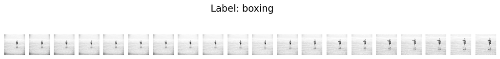

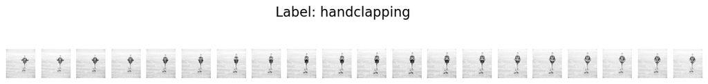

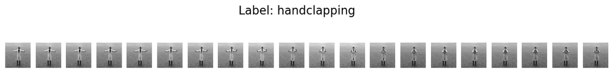

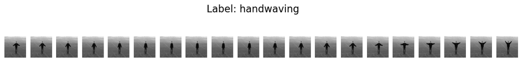

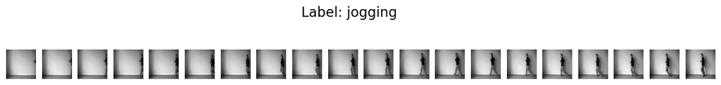

```python
import numpy as np
import matplotlib.pyplot as plt

# Assuming your data is stored in the variables data_array and label_array
# Replace these with your actual variable names
_, label_to_class = sequencesExtractor.get_encoding_dicts()
data_array = train_sequences # Replace this with your actual data
label_array = train_target_arr  # Replace this with your actual labels

# Choose a random index to select one sequence
random_indices = np.random.choice(len(data_array), size=5, replace=False)

for random_index in random_indices:
    # Get the random sequence and its label
    selected_sequence = data_array[random_index]
    label = label_array[random_index]

    # Visualize the sequence
    fig, axes = plt.subplots(1, selected_sequence.shape[0], figsize=(15, 2))

    # Display images in the sequence
    for i in range(selected_sequence.shape[0]):
        axes[i].imshow(selected_sequence[i, 0, :, :], cmap='gray')
        axes[i].axis('off')

    # Set the label as the title of the plot
    fig.suptitle(f"Label: {label_to_class[label]}", fontsize=16)

    # Show the plot
    plt.show()
```

```python
from torch.utils.data import Dataset, DataLoader
```

```python
#This is also a valid way to create a dataset, I was just looking for a bug and created create_dataloaders function and stuck by it
class KTHDataset(Dataset):
    def __init__(self, sequences, labels):
        self.sequences = sequences
        self.labels = labels

    def __len__(self):
        return len(self.sequences)

    def __getitem__(self, idx):
        sequence = self.sequences[idx]
        label = self.labels[idx]

        return sequence, label
```

```python
train_dataloader = create_dataloaders(train_sequences,train_target_arr, batch_size=batch_size, shuffle=True)
val_dataloader = create_dataloaders(val_sequences,val_target_arr, batch_size=batch_size, shuffle=True)
```

```python
if(not os.path.exists("models")):
    os.makedirs("models")
```

# Self-implemented LSTM cells

## LSTM - Cell

```python
class OurLSTMCell(nn.Module):
    def __init__(self, input_size, hidden_size):
        super(OurLSTMCell, self).__init__()
        self.input_size = input_size
        self.hidden_size = hidden_size

        # Input gate
        self.W_ii = nn.Parameter(torch.Tensor(hidden_size, input_size))
        self.W_hi = nn.Parameter(torch.Tensor(hidden_size, hidden_size))
        self.b_ii = nn.Parameter(torch.Tensor(hidden_size))
        self.b_hi = nn.Parameter(torch.Tensor(hidden_size))

        # Forget gate
        self.W_if = nn.Parameter(torch.Tensor(hidden_size, input_size))
        self.W_hf = nn.Parameter(torch.Tensor(hidden_size, hidden_size))
        self.b_if = nn.Parameter(torch.Tensor(hidden_size))
        self.b_hf = nn.Parameter(torch.Tensor(hidden_size))

        # Cell gate
        self.W_ig = nn.Parameter(torch.Tensor(hidden_size, input_size))
        self.W_hg = nn.Parameter(torch.Tensor(hidden_size, hidden_size))
        self.b_ig = nn.Parameter(torch.Tensor(hidden_size))
        self.b_hg = nn.Parameter(torch.Tensor(hidden_size))

        # Output gate
        self.W_io = nn.Parameter(torch.Tensor(hidden_size, input_size))
        self.W_ho = nn.Parameter(torch.Tensor(hidden_size, hidden_size))
        self.b_io = nn.Parameter(torch.Tensor(hidden_size))
        self.b_ho = nn.Parameter(torch.Tensor(hidden_size))

        self.init_weights()

    def init_weights(self):
        for p in self.parameters():
            # dimension greater equal to 2 is typically associated with weight tensors
            if p.data.ndimension() >= 2:
                nn.init.xavier_uniform_(p.data)
            else:
            # bias tensors are commonly initialized to 0
                nn.init.zeros_(p.data)


    def forward(self, x, init_states=None):
        # bs, _ = x.size()

        # Access prior hidden state if existent, else initialize to zero (i.e. future is unknown)
        h_t, c_t = (torch.zeros(self.hidden_size).to(x.device),
                    torch.zeros(self.hidden_size).to(x.device)) if init_states is None else init_states

        # We note: In a perfect world, this should be parallelized
        # Input gate
        i_t = torch.sigmoid(x @ self.W_ii.t() + self.b_ii + h_t @ self.W_hi.t() + self.b_hi)

        # Forget gate
        f_t = torch.sigmoid(x @ self.W_if.t() + self.b_if + h_t @ self.W_hf.t() + self.b_hf)

        # Cell gate
        g_t = torch.tanh(x @ self.W_ig.t() + self.b_ig + h_t @ self.W_hg.t() + self.b_hg)

        # Output gate
        o_t = torch.sigmoid(x @ self.W_io.t() + self.b_io + h_t @ self.W_ho.t() + self.b_ho)

        # Note: * is the Hadamard product
        # Update cell state
        c_t = f_t * c_t + i_t * g_t

        # Update hidden state
        h_t = o_t * torch.tanh(c_t)

        return h_t, c_t
```

## ConvLSTM cell

We adhered strictly to the paper. The only thing we changed was the additional usage of Hadamard products, in order to stay closer to our original LSTM. This appears to be a popular choice with many applications.

```python
class ConvLSTMCell(nn.Module):
    def __init__(self, channels, input_size, kernel_size = 3):
        '''
        Params:

        channels: number of channels, which is used as input and output
        input_size: The input size of the image
        kernel_size: size of the convolutional kernel
        '''
        super(ConvLSTMCell, self).__init__()

        self.input_size = input_size
        self.kernel_size = kernel_size

        # Input gate
        self.W_ii = nn.Conv2d(in_channels=channels, out_channels=channels, kernel_size=3, stride=1, padding=1)
        self.W_hi = nn.Conv2d(in_channels=channels, out_channels=channels, kernel_size=3, stride=1, padding=1)
        self.b_i = nn.Parameter(torch.zeros(channels, input_size, input_size))

        # Forget gate
        self.W_if = nn.Conv2d(in_channels=channels, out_channels=channels, kernel_size=3, stride=1, padding=1)
        self.W_hf = nn.Conv2d(in_channels=channels, out_channels=channels, kernel_size=3, stride=1, padding=1)
        self.b_f = nn.Parameter(torch.zeros(channels, input_size, input_size))

        # Cell gate
        self.W_ig = nn.Conv2d(in_channels=channels, out_channels=channels, kernel_size=3, stride=1, padding=1)
        self.W_hg = nn.Conv2d(in_channels=channels, out_channels=channels, kernel_size=3, stride=1, padding=1)
        self.b_g = nn.Parameter(torch.zeros(channels, input_size, input_size))

        # Output gate
        self.W_io = nn.Conv2d(in_channels=channels, out_channels=channels, kernel_size=3, stride=1, padding=1)
        self.W_ho = nn.Conv2d(in_channels=channels, out_channels=channels, kernel_size=3, stride=1, padding=1)
        self.b_o = nn.Parameter(torch.zeros(channels, input_size, input_size))

        self.init_weights()

    # Same as above
    def init_weights(self):
        for p in self.parameters():
            if p.data.ndimension() >= 2:
                nn.init.xavier_uniform_(p.data)
            else:
                nn.init.zeros_(p.data)

    def forward(self, x, init_states=None):
        bs, channels, rows, cols = x.size()

        h_t, c_t = (torch.zeros(self.input_size).to(x.device),
                    torch.zeros(self.input_size)) if init_states is None else init_states


        # Input gate
        i_t = torch.sigmoid(self.W_ii(x) + self.b_i + self.W_hi(h_t))

        # Forget gate
        f_t = torch.sigmoid(self.W_if(x) + self.W_hf(h_t) + self.b_f)

        # Cell gate
        g_t = torch.tanh(self.W_ig(x) + self.b_g + self.W_hg(h_t))

        # Output gate
        o_t = torch.sigmoid(self.W_io(x) + self.b_o + self.W_ho(h_t))

        # Update cell state
        c_t = f_t * c_t + i_t * g_t

        # Update hidden state
        h_t = o_t * torch.tanh(c_t)

        return h_t, c_t
```

```python
class ConvBlock(nn.Module):
    """
    Encapuslation of a convolutional block (conv + activation + pooling)
    """
    def __init__(self, in_ch, out_ch, k_size, pool=False, dropout_prob = 0.2, mxpool_stride=1):
        super(ConvBlock, self).__init__()
        layers = []
        layers.append(nn.Conv2d(in_ch, out_ch, k_size))
        layers.append(nn.ReLU())
        if(pool):
            layers.append(nn.MaxPool2d(kernel_size=2, stride = mxpool_stride))
       # layers.append(nn.Dropout(p=dropout_prob))
        self.module = nn.Sequential(*layers)
    def forward(self, x):
        return(self.module(x))
```

```python
class ConvRecurrentClassifier(nn.Module):
    def __init__(self, input_channels, hidden_size, num_classes,num_layers = 10, mode="random", recurrent_module="lstm"):
        assert mode in ["zeros", "random"]
        super(ConvRecurrentClassifier, self).__init__()
        self.mode = mode
        self.num_layers = num_layers
        self.hidden_dim = hidden_size

        self.conv_encoder = nn.Sequential(
            # Add more convolutional layers if needed
            ConvBlock(3, 16, 3, pool=False),
            ConvBlock(16, 32, 3, pool=True, mxpool_stride=2),
            ConvBlock(32, 64, 3, pool=False),
            ConvBlock(64, 128, 3, pool=True, mxpool_stride=2),
            ConvBlock(128, 256, 3, pool=False),
            ConvBlock(256, 512, 3, pool=True, mxpool_stride=2),
            ConvBlock(512, 1024, 3, pool=False)
        )

        #Recurrent Module
        if recurrent_module == "lstm":
            # LSTM model
            lstms = []
            for i in range(num_layers):
                in_size = 4096 if i == 0 else self.hidden_dim
                lstms.append( nn.LSTMCell(input_size=in_size, hidden_size=self.hidden_dim) )
            self.lstm = nn.ModuleList(lstms)
            self.recurrent_module = self._LSTMforward
        elif recurrent_module == "gru":
            grus = []
            for i in range(num_layers):
                in_size = 4096 if i == 0 else self.hidden_dim
                grus.append(nn.GRUCell(input_size=in_size, hidden_size=self.hidden_dim))
            self.gru = nn.ModuleList(grus)
            self.recurrent_module = self._GRUforward
        elif recurrent_module == "our_lstm":
            # LSTM model
            lstms = []
            for i in range(num_layers):
                in_size = 4096 if i == 0 else self.hidden_dim
                lstms.append(OurLSTMCell(input_size=in_size, hidden_size=self.hidden_dim))
            self.lstm = nn.ModuleList(lstms)
            self.recurrent_module = self._OurLSTMforward



        #Recurrent Module
        # self.lstm = nn.LSTM(input_size=4096, hidden_size=hidden_size, batch_first=True)
        # Classifier
        self.classifier = nn.Sequential(
            nn.Linear(hidden_size, num_classes)
        )

    def _OurLSTMforward(self, embeddings, b_size):
        h, c = self.lstm_init_state(b_size=b_size, device=device)
        lstm_out = []
        for i in range(embeddings.shape[1]):
            lstm_input = embeddings[:, i, :]
            # iterating over LSTM Cells
            for j, lstm_cell in enumerate(self.lstm):
                h[j], c[j] = lstm_cell(lstm_input, init_states = (h[j], c[j]))
                lstm_input = h[j]
            lstm_out.append(lstm_input)
        lstm_out = torch.stack(lstm_out, dim=1)
        # Take the output from the last time step
        out = lstm_out[:, -1, :]
        return out

    def _LSTMforward(self, embeddings, b_size):
        h, c = self.lstm_init_state(b_size=b_size, device=device)
        lstm_out = []
        for i in range(embeddings.shape[1]):
            lstm_input = embeddings[:, i, :]
            # iterating over LSTM Cells
            for j, lstm_cell in enumerate(self.lstm):
                h[j], c[j] = lstm_cell(lstm_input, (h[j], c[j]))
                lstm_input = h[j]
            lstm_out.append(lstm_input)
        lstm_out = torch.stack(lstm_out, dim=1)
        # Take the output from the last time step
        out = lstm_out[:, -1, :]
        return out

    def _GRUforward(self, embeddings, b_size):
        h = self.gru_init_state(b_size=b_size, device=device)
        gru_out = []
        for i in range(embeddings.shape[1]):
            gru_input = embeddings[:, i, :]
            # iterating over GRU Cells
            for j, gru_cell in enumerate(self.gru):
                h[j] = gru_cell(gru_input, h[j])
                gru_input = h[j]
            gru_out.append(gru_input)
        gru_out = torch.stack(gru_out, dim=1)
        # Take the output from the last time step
        out = gru_out[:, -1, :]
        return out

    def forward(self, x):
        b_size, seq_length, n_channels, width, height = x.shape
        # Reshape input to (batch_size, channels, sequence_length*height, width)
        x = x.view(b_size*seq_length, n_channels, width, height)

       # h, c = self.init_state(b_size=b_size, device=device)
         # Convolutional Encoder
        x = self.conv_encoder(x)

        # Reshape for LSTM
        embeddings = x.view(b_size, seq_length, -1)
        # Recurrent Module
        out = self.recurrent_module(embeddings, b_size)


        # Classifier
        out = self.classifier(out)

        return out
    def lstm_init_state(self, b_size, device):
        """ Initializing hidden and cell state """
        if(self.mode == "zeros"):
            h = [torch.zeros(b_size, self.hidden_dim).to(device) for _ in range(self.num_layers)]
            c = [torch.zeros(b_size, self.hidden_dim).to(device) for _ in range(self.num_layers)]
        elif(self.mode == "random"):
            h = [torch.zeros(b_size, self.hidden_dim).to(device) for _ in range(self.num_layers)]
            c = [torch.zeros(b_size, self.hidden_dim).to(device) for _ in range(self.num_layers)]
        return h, c

    def gru_init_state(self, b_size, device):
        """ Initializing hidden state """
        if(self.mode == "zeros"):
            h = [torch.zeros(b_size, self.hidden_dim).to(device) for _ in range(self.num_layers)]
        elif(self.mode == "random"):
            h = [torch.randn(b_size, self.hidden_dim).to(device) for _ in range(self.num_layers)]
        return h
```

## Recurrent Network with ConvLSTM

We updated the Conv Block to support padding, in order to maintain larger image size with multiple convolutional layers. Additionally we dropped some convolutional layers with padding. A larger dimension of the input image was needed to ensure that a usage of the ConvLSTM was sensible.

```python
class ConvBlock_2(nn.Module):
    """
    Encapuslation of a convolutional block (conv + activation + pooling)
    """
    def __init__(self, in_ch, out_ch, k_size, pool=False, dropout_prob = 0.2, mxpool_stride=1, pad=1):
        super(ConvBlock_2, self).__init__()
        layers = []
        layers.append(nn.Conv2d(in_ch, out_ch, k_size, padding=pad))
        layers.append(nn.ReLU())
        if(pool):
            layers.append(nn.MaxPool2d(kernel_size=2, stride = mxpool_stride))
       # layers.append(nn.Dropout(p=dropout_prob))
        self.module = nn.Sequential(*layers)
    def forward(self, x):
        return(self.module(x))
```

```python
class ConvLSTMRecurrentClassifier(nn.Module):
    def __init__(self, input_channels, hidden_size, num_classes,num_layers = 3, mode="random", recurrent_module="lstm"):
        assert mode in ["zeros", "random"]
        super(ConvLSTMRecurrentClassifier, self).__init__()
        self.mode = mode
        self.num_layers = num_layers
        self.hidden_dim = hidden_size


        self.conv_encoder = nn.Sequential(

            ConvBlock_2(3, 16, 3, pool=False),
            ConvBlock_2(16, 32, 3, pool=True, mxpool_stride=2),
            ConvBlock_2(32, 64, 3, pool=False),
            ConvBlock_2(64, 128, 3, pool=True, mxpool_stride=2),

        )

        self.lstms = []
        # ConvLSTM cells
        self.lstms.append(ConvLSTMCell(128, 16))
        for _ in range(num_layers - 1):
            self.lstms.append((ConvLSTMCell(128, hidden_size)))
        self.lstm = nn.ModuleList(self.lstms)

        self.classifier = nn.Sequential(
            nn.Linear(hidden_size*hidden_size*128, num_classes)
        )

    def forward(self, x):
        # x: (batch_size, sequence_length, input_size)
        batch_size = x.shape[0]
        seq_length = x.shape[1]
        channels = x.shape[2]
        height = x.shape[3]
        width = x. shape[4]

        final_channels = 128

        # Use Conv Encoder
        x = x.view(batch_size*seq_length, channels, width, height)

        x = self.conv_encoder(x)

        x = x.view(batch_size, seq_length, final_channels, self.hidden_dim, self.hidden_dim)

        # Initial hidden and cell states
        h = [torch.zeros(final_channels, self.hidden_dim, self.hidden_dim).to(device) for _ in range(self.num_layers)]
        c = [torch.zeros(final_channels, self.hidden_dim, self.hidden_dim).to(device) for _ in range(self.num_layers)]

        # Process each time step using ConvLSTM cells

        for i in range(x.shape[1]):
            lstm_input = x[:, i, :, :]
            # iterating over ConvLSTM Cells
            for j, lstm_cell in enumerate(self.lstm):
                h[j], c[j] = lstm_cell(lstm_input, init_states =  (h[j], c[j]))
                lstm_input = h[j]

        x = h[-1].reshape(batch_size, -1)
        # Fully connected layer for classification (using the output from the last time step)

        out = self.classifier(x)

        return out
```

## Defining training loop

### (for some reason, i've got bugs when putting it in utils)

```python
@torch.no_grad()
def eval_model(chosen_model, eval_loader, criterion, device, model_type = "whatever"):
    """
    Evaluating the model for either validation or test.

    Parameters:
    - model (nn.Module): The trained neural network model to be evaluated.
    - eval_loader (torch.utils.data.DataLoader): DataLoader for the validation or test dataset.
    - criterion (nn.Module): The loss function.
    - device (torch.device): The device on which to perform evaluation (e.g., 'cuda' or 'cpu').

    Returns:
    - float: Accuracy on the validation or test dataset.
    - float: Mean loss on the validation or test dataset.
    """
    correct = 0
    total = 0
    loss_list = []

    for sequences, labels in eval_loader:
        inputs = sequences.to(device)
        labels = labels.to(device)
        if model_type == "resnet":
            inputs = torch.movedim(inputs, 1, 2)

        # Forward pass only to get logits/output
        outputs = chosen_model(inputs)

        loss = criterion(outputs, labels)
        loss_list.append(loss.item())

        # Get predictions from the maximum value
        preds = torch.argmax(outputs, dim=1)
        correct += len( torch.where(preds==labels)[0] )
        total += len(labels)

    # Total correct predictions and loss
    accuracy = correct / total * 100
    loss = np.mean(loss_list)
    return accuracy, loss
```

```python
def train_model_v4(num_epochs, chosen_model, train_dataloader, val_dataloader, optimizer, criterion, device, model_type = "whatever",
                  scheduler = None):
    loss_hist = []
    train_acc_hist = []
    valid_acc_hist = []
    valid_loss_hist = []
    best_loss = 100
    for epoch in range(num_epochs):
        loss_list = []
        acc_list = []
        progress_bar = tqdm(enumerate(train_dataloader), total=len(train_dataloader))
        for i, (sequences, labels) in progress_bar:
            sequences = sequences.to(device)
            labels = labels.to(device)
            if model_type == "resnet":
                sequences = torch.movedim(sequences, 1,2)
            # Clear gradients w.r.t. parameters
            optimizer.zero_grad()

            # Forward pass to get output/logits
            outputs = chosen_model(sequences)

            # Calculate Loss: softmax --> cross entropy loss
            loss = criterion(outputs, labels)
            loss_list.append(loss.item())

            with torch.no_grad():
                predicted = outputs.argmax(dim=-1)
                correct = (predicted == labels).sum().item()
                accuracy = correct/labels.shape[0] * 100
            acc_list.append(accuracy)
            # Getting gradients w.r.t. parameters
            loss.backward()
           # torch.nn.utils.clip_grad_norm_(model.parameters(), max_norm=2.0, norm_type=2.0)
            # Updating parameters
            optimizer.step()
            if scheduler:
                scheduler.step()

            progress_bar.set_description(f"Epoch {epoch+1} Iter {i+1}: loss {loss.item():.5f}. train accuracy: {accuracy}")

        loss_hist.append(np.mean(loss_list))
        train_acc_hist.append(np.mean(acc_list))
        val_accuracy, valid_loss = eval_model(chosen_model, val_dataloader, criterion, device, model_type)
        if valid_loss < best_loss:
                best_loss = valid_loss
                torch.save({
                    'epoch': epoch,
                    'model_state_dict': chosen_model.state_dict(),
                    'optimizer_state_dict': optimizer.state_dict(),
                }, f"models/{model_type}_epoch_{epoch}.pth")
        print(f"Val accuracy at epoch {epoch}: {round(val_accuracy, 2)}%")
        valid_loss_hist.append(valid_loss)
        valid_acc_hist.append(val_accuracy)
    return train_acc_hist, loss_hist, valid_acc_hist, valid_loss_hist
```

```python
print(len(sequencesExtractor.get_classes()))
```

```
6
```

```python
model_gru = ConvRecurrentClassifier(input_channels=3, hidden_size=512, num_classes=len(sequencesExtractor.get_classes()),recurrent_module="gru")
```

```python
device = torch.device("cuda" if torch.cuda.is_available() else "cpu")
criterion = nn.CrossEntropyLoss()  # Note, that this already includes a Softmax!
optimizer = torch.optim.AdamW(model_gru.parameters(), lr=0.001)
#scheduler = torch.optim.lr_scheduler.OneCycleLR(optimizer, max_lr=0.01, steps_per_epoch=len(train_dataloader), epochs=num_epochs)
model_gru = model_gru.to(device)
```

```python
model_parameters = filter(lambda p: p.requires_grad, model_gru.parameters())
params = sum([np.prod(p.size()) for p in model_parameters])
print(params)
```

```
27559846
```

```python
torch.cuda.empty_cache()
```

```python
# from template import utils
```

```python
#training GRU
train_acc_hist, train_loss_hist, val_acc_hist, val_loss_hist = train_model_v4(num_epochs,
                                                                              model_gru,
                                                                              train_dataloader,
                                                                              val_dataloader,
                                                                              optimizer,
                                                                              criterion,
                                                                              device,
                                                                              "gru")
```

```
Epoch 1 Iter 31: loss 1.41941. train accuracy: 34.146341463414636: 100%|█████████████████████████████| 31/31 [00:17<00:00,  1.72it/s]
```

```
Val accuracy at epoch 0: 37.16%
```

```
Epoch 2 Iter 31: loss 1.20381. train accuracy: 31.70731707317073: 100%|██████████████████████████████| 31/31 [00:17<00:00,  1.81it/s]
```

```
Val accuracy at epoch 1: 25.83%
```

```
Epoch 3 Iter 31: loss 1.49823. train accuracy: 26.82926829268293: 100%|██████████████████████████████| 31/31 [00:17<00:00,  1.74it/s]
```

```
Val accuracy at epoch 2: 33.02%
```

```
Epoch 4 Iter 31: loss 1.52101. train accuracy: 40.243902439024396: 100%|█████████████████████████████| 31/31 [00:17<00:00,  1.77it/s]
```

```
Val accuracy at epoch 3: 33.8%
```

```
Epoch 5 Iter 31: loss 1.84322. train accuracy: 12.195121951219512: 100%|█████████████████████████████| 31/31 [00:17<00:00,  1.76it/s]
```

```
Val accuracy at epoch 4: 16.36%
```

```
Epoch 6 Iter 31: loss 1.80886. train accuracy: 17.073170731707318: 100%|█████████████████████████████| 31/31 [00:18<00:00,  1.69it/s]
```

```
Val accuracy at epoch 5: 15.99%
```

```
Epoch 7 Iter 31: loss 1.78383. train accuracy: 19.51219512195122: 100%|██████████████████████████████| 31/31 [00:17<00:00,  1.78it/s]
```

```
Val accuracy at epoch 6: 18.84%
```

```
Epoch 8 Iter 31: loss 1.76306. train accuracy: 28.04878048780488: 100%|██████████████████████████████| 31/31 [00:17<00:00,  1.79it/s]
```

```
Val accuracy at epoch 7: 18.63%
```

```
Epoch 9 Iter 31: loss 1.77691. train accuracy: 21.951219512195124: 100%|█████████████████████████████| 31/31 [00:16<00:00,  1.85it/s]
```

```
Val accuracy at epoch 8: 19.77%
```

```
Epoch 10 Iter 31: loss 1.75710. train accuracy: 28.04878048780488: 100%|█████████████████████████████| 31/31 [00:18<00:00,  1.71it/s]
```

```
Val accuracy at epoch 9: 21.27%
```

```
Epoch 11 Iter 31: loss 1.76299. train accuracy: 26.82926829268293: 100%|█████████████████████████████| 31/31 [00:16<00:00,  1.87it/s]
```

```
Val accuracy at epoch 10: 21.58%
```

```
Epoch 12 Iter 31: loss 1.76277. train accuracy: 25.609756097560975: 100%|████████████████████████████| 31/31 [00:18<00:00,  1.72it/s]
```

```
Val accuracy at epoch 11: 20.24%
```

```
Epoch 13 Iter 31: loss 1.75620. train accuracy: 28.04878048780488: 100%|█████████████████████████████| 31/31 [00:17<00:00,  1.76it/s]
```

```
Val accuracy at epoch 12: 22.1%
```

```
Epoch 14 Iter 31: loss 1.74335. train accuracy: 29.268292682926827: 100%|████████████████████████████| 31/31 [00:17<00:00,  1.80it/s]
```

```
Val accuracy at epoch 13: 22.0%
```

```
Epoch 15 Iter 31: loss 1.76377. train accuracy: 24.390243902439025: 100%|████████████████████████████| 31/31 [00:17<00:00,  1.82it/s]
```

```
Val accuracy at epoch 14: 21.07%
```

```
Epoch 16 Iter 31: loss 1.75424. train accuracy: 28.04878048780488: 100%|█████████████████████████████| 31/31 [00:17<00:00,  1.78it/s]
```

```
Val accuracy at epoch 15: 20.08%
```

```
Epoch 17 Iter 31: loss 1.77820. train accuracy: 24.390243902439025: 100%|████████████████████████████| 31/31 [00:17<00:00,  1.75it/s]
```

```
Val accuracy at epoch 16: 21.27%
```

```
Epoch 18 Iter 31: loss 1.76223. train accuracy: 30.48780487804878: 100%|█████████████████████████████| 31/31 [00:17<00:00,  1.80it/s]
```

```
Val accuracy at epoch 17: 21.84%
```

```
Epoch 19 Iter 31: loss 1.75048. train accuracy: 25.609756097560975: 100%|████████████████████████████| 31/31 [00:18<00:00,  1.71it/s]
```

```
Val accuracy at epoch 18: 20.29%
```

```
Epoch 20 Iter 31: loss 1.77109. train accuracy: 26.82926829268293: 100%|█████████████████████████████| 31/31 [00:18<00:00,  1.70it/s]
```

```
Val accuracy at epoch 19: 21.01%
```

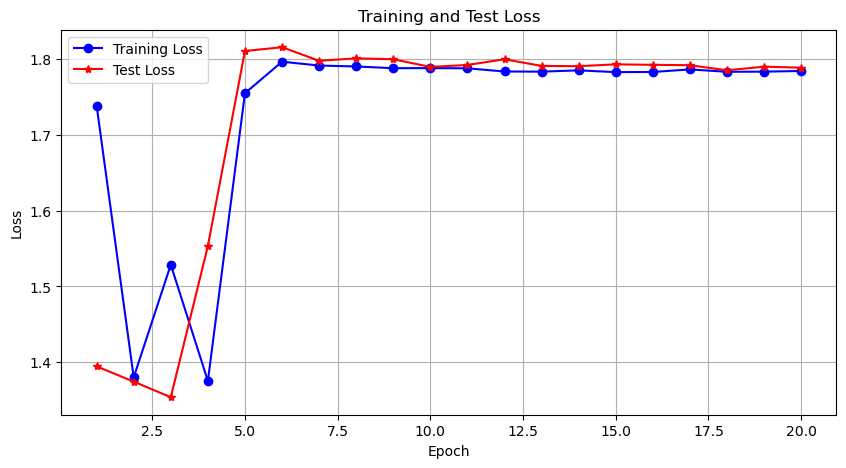

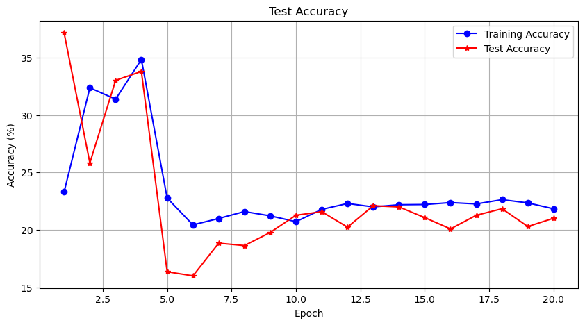

```python
utils.plot_loss_epoch(train_loss_hist, val_loss_hist)
utils.plot_accuracy_epoch(val_acc_hist, train_acc_hist)
```

```python
# training LSTMs
model_lstm = ConvRecurrentClassifier(input_channels=3, hidden_size=512, num_classes=len(sequencesExtractor.get_classes()),recurrent_module="lstm")
device = torch.device("cuda" if torch.cuda.is_available() else "cpu")
criterion = nn.CrossEntropyLoss()  # Note, that this already includes a Softmax!
optimizer = torch.optim.AdamW(model_lstm.parameters(), lr=0.001)
#scheduler = torch.optim.lr_scheduler.OneCycleLR(optimizer, max_lr=0.01, steps_per_epoch=len(train_dataloader), epochs=num_epochs)
model_lstm = model_lstm.to(device)
```

```python
#training LSTMs
train_acc_hist, train_loss_hist, val_acc_hist, val_loss_hist = train_model_v4(num_epochs,
                                                                              model_lstm,
                                                                              train_dataloader,
                                                                              val_dataloader,
                                                                              optimizer,
                                                                              criterion,
                                                                              device,
                                                                              "lstm")
```

```
Epoch 1 Iter 31: loss 1.75252. train accuracy: 29.268292682926827: 100%|█████████████████████████████| 31/31 [00:27<00:00,  1.14it/s]
```

```
Val accuracy at epoch 0: 23.5%
```

```
Epoch 2 Iter 31: loss 1.74566. train accuracy: 29.268292682926827: 100%|█████████████████████████████| 31/31 [00:22<00:00,  1.39it/s]
```

```
Val accuracy at epoch 1: 23.5%
```

```
Epoch 3 Iter 31: loss 1.74395. train accuracy: 29.268292682926827: 100%|█████████████████████████████| 31/31 [00:25<00:00,  1.20it/s]
```

```
Val accuracy at epoch 2: 23.5%
```

```
Epoch 4 Iter 31: loss 1.74480. train accuracy: 29.268292682926827: 100%|█████████████████████████████| 31/31 [00:28<00:00,  1.09it/s]
```

```
Val accuracy at epoch 3: 23.5%
```

```
Epoch 5 Iter 31: loss 1.74597. train accuracy: 29.268292682926827: 100%|█████████████████████████████| 31/31 [00:25<00:00,  1.19it/s]
```

```
Val accuracy at epoch 4: 23.5%
```

```
Epoch 6 Iter 31: loss 1.74546. train accuracy: 29.268292682926827: 100%|█████████████████████████████| 31/31 [00:26<00:00,  1.17it/s]
```

```
Val accuracy at epoch 5: 23.5%
```

```
Epoch 7 Iter 31: loss 1.74477. train accuracy: 29.268292682926827: 100%|█████████████████████████████| 31/31 [00:23<00:00,  1.32it/s]
```

```
Val accuracy at epoch 6: 23.5%
```

```
Epoch 8 Iter 31: loss 1.74442. train accuracy: 29.268292682926827: 100%|█████████████████████████████| 31/31 [00:26<00:00,  1.18it/s]
```

```
Val accuracy at epoch 7: 23.5%
```

```
Epoch 9 Iter 31: loss 1.74420. train accuracy: 29.268292682926827: 100%|█████████████████████████████| 31/31 [00:28<00:00,  1.11it/s]
```

```
Val accuracy at epoch 8: 23.5%
```

```
Epoch 10 Iter 31: loss 1.74401. train accuracy: 29.268292682926827: 100%|████████████████████████████| 31/31 [00:24<00:00,  1.28it/s]
```

```
Val accuracy at epoch 9: 23.5%
```

```
Epoch 11 Iter 31: loss 1.74383. train accuracy: 29.268292682926827: 100%|████████████████████████████| 31/31 [00:25<00:00,  1.23it/s]
```

```
Val accuracy at epoch 10: 23.5%
```

```
Epoch 12 Iter 31: loss 1.74368. train accuracy: 29.268292682926827: 100%|████████████████████████████| 31/31 [00:27<00:00,  1.12it/s]
```

```
Val accuracy at epoch 11: 23.5%
```

```
Epoch 13 Iter 31: loss 1.74354. train accuracy: 29.268292682926827: 100%|████████████████████████████| 31/31 [00:28<00:00,  1.10it/s]
```

```
Val accuracy at epoch 12: 23.5%
```

```
Epoch 14 Iter 31: loss 1.74342. train accuracy: 29.268292682926827: 100%|████████████████████████████| 31/31 [00:28<00:00,  1.09it/s]
```

```
Val accuracy at epoch 13: 23.5%
```

```
Epoch 15 Iter 31: loss 1.74331. train accuracy: 29.268292682926827: 100%|████████████████████████████| 31/31 [00:22<00:00,  1.39it/s]
```

```
Val accuracy at epoch 14: 23.5%
```

```
Epoch 16 Iter 31: loss 1.74320. train accuracy: 29.268292682926827: 100%|████████████████████████████| 31/31 [00:26<00:00,  1.18it/s]
```

```
Val accuracy at epoch 15: 23.5%
```

```
Epoch 17 Iter 31: loss 1.74311. train accuracy: 29.268292682926827: 100%|████████████████████████████| 31/31 [00:27<00:00,  1.12it/s]
```

```
Val accuracy at epoch 16: 23.5%
```

```
Epoch 18 Iter 31: loss 1.74302. train accuracy: 29.268292682926827: 100%|████████████████████████████| 31/31 [00:26<00:00,  1.16it/s]
```

```
Val accuracy at epoch 17: 23.5%
```

```
Epoch 19 Iter 31: loss 1.74295. train accuracy: 29.268292682926827: 100%|████████████████████████████| 31/31 [00:24<00:00,  1.27it/s]
```

```
Val accuracy at epoch 18: 23.5%
```

```
Epoch 20 Iter 31: loss 1.74289. train accuracy: 29.268292682926827: 100%|████████████████████████████| 31/31 [00:27<00:00,  1.14it/s]
```

```
Val accuracy at epoch 19: 23.5%
```

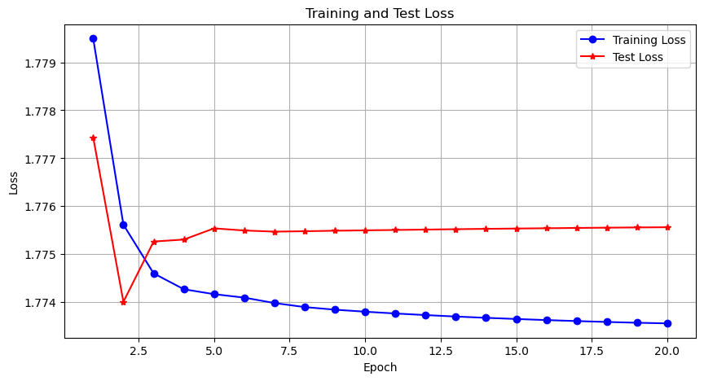

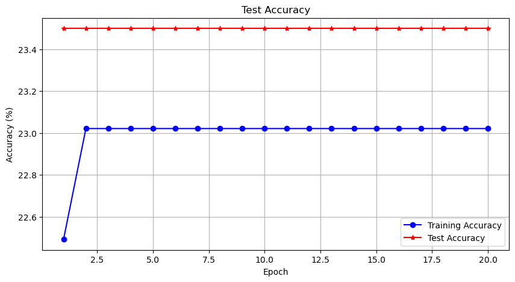

```python
utils.plot_loss_epoch(train_loss_hist, val_loss_hist)
utils.plot_accuracy_epoch(val_acc_hist, train_acc_hist)
```

```python
#training our own lstm
model_our_lstm = ConvRecurrentClassifier(input_channels=3, hidden_size=512, num_classes=len(sequencesExtractor.get_classes()),recurrent_module="our_lstm")
device = torch.device("cuda" if torch.cuda.is_available() else "cpu")
criterion = nn.CrossEntropyLoss()  # Note, that this already includes a Softmax!
optimizer = torch.optim.AdamW(model_our_lstm.parameters(), lr=0.001)
#scheduler = torch.optim.lr_scheduler.OneCycleLR(optimizer, max_lr=0.01, steps_per_epoch=len(train_dataloader), epochs=num_epochs)
model_our_lstm = model_our_lstm.to(device)
```

```python
train_acc_hist, train_loss_hist, val_acc_hist, val_loss_hist = train_model_v4(num_epochs,
                                                                              model_our_lstm,
                                                                              train_dataloader,
                                                                              val_dataloader,
                                                                              optimizer,
                                                                              criterion,
                                                                              device,
                                                                              "our_lstm")
```

```
Epoch 1 Iter 31: loss 1.75322. train accuracy: 29.268292682926827: 100%|█████████████████████████████| 31/31 [00:43<00:00,  1.40s/it]
```

```
Val accuracy at epoch 0: 23.5%
```

```
Epoch 2 Iter 31: loss 1.74867. train accuracy: 29.268292682926827: 100%|█████████████████████████████| 31/31 [00:40<00:00,  1.30s/it]
```

```
Val accuracy at epoch 1: 23.5%
```

```
Epoch 3 Iter 31: loss 1.70536. train accuracy: 30.48780487804878: 100%|██████████████████████████████| 31/31 [00:40<00:00,  1.29s/it]
```

```
Val accuracy at epoch 2: 23.5%
```

```
Epoch 4 Iter 31: loss 1.75290. train accuracy: 29.268292682926827: 100%|█████████████████████████████| 31/31 [00:41<00:00,  1.34s/it]
```

```
Val accuracy at epoch 3: 23.5%
```

```
Epoch 5 Iter 31: loss 1.74608. train accuracy: 29.268292682926827: 100%|█████████████████████████████| 31/31 [00:42<00:00,  1.37s/it]
```

```
Val accuracy at epoch 4: 23.5%
```

```
Epoch 6 Iter 31: loss 1.74664. train accuracy: 29.268292682926827: 100%|█████████████████████████████| 31/31 [00:38<00:00,  1.24s/it]
```

```
Val accuracy at epoch 5: 23.5%
```

```
Epoch 7 Iter 31: loss 1.74663. train accuracy: 29.268292682926827: 100%|█████████████████████████████| 31/31 [00:38<00:00,  1.26s/it]
```

```
Val accuracy at epoch 6: 23.5%
```

```
Epoch 8 Iter 31: loss 1.74599. train accuracy: 29.268292682926827: 100%|█████████████████████████████| 31/31 [00:41<00:00,  1.34s/it]
```

```
Val accuracy at epoch 7: 23.5%
```

```
Epoch 9 Iter 31: loss 1.74562. train accuracy: 29.268292682926827: 100%|█████████████████████████████| 31/31 [00:40<00:00,  1.32s/it]
```

```
Val accuracy at epoch 8: 23.5%
```

```
Epoch 10 Iter 31: loss 1.74537. train accuracy: 29.268292682926827: 100%|████████████████████████████| 31/31 [00:38<00:00,  1.26s/it]
```

```
Val accuracy at epoch 9: 23.5%
```

```
Epoch 11 Iter 31: loss 1.74516. train accuracy: 29.268292682926827: 100%|████████████████████████████| 31/31 [00:38<00:00,  1.24s/it]
```

```
Val accuracy at epoch 10: 23.5%
```

```
Epoch 12 Iter 31: loss 1.74499. train accuracy: 29.268292682926827: 100%|████████████████████████████| 31/31 [00:37<00:00,  1.21s/it]
```

```
Val accuracy at epoch 11: 23.5%
```

```
Epoch 13 Iter 31: loss 1.74483. train accuracy: 29.268292682926827: 100%|████████████████████████████| 31/31 [00:39<00:00,  1.27s/it]
```

```
Val accuracy at epoch 12: 23.5%
```

```
Epoch 14 Iter 31: loss 1.74469. train accuracy: 29.268292682926827: 100%|████████████████████████████| 31/31 [00:38<00:00,  1.25s/it]
```

```
Val accuracy at epoch 13: 23.5%
```

```
Epoch 15 Iter 31: loss 1.74455. train accuracy: 29.268292682926827: 100%|████████████████████████████| 31/31 [00:35<00:00,  1.15s/it]
```

```
Val accuracy at epoch 14: 23.5%
```

```
Epoch 16 Iter 31: loss 1.74443. train accuracy: 29.268292682926827: 100%|████████████████████████████| 31/31 [00:36<00:00,  1.16s/it]
```

```
Val accuracy at epoch 15: 23.5%
```

```
Epoch 17 Iter 31: loss 1.74432. train accuracy: 29.268292682926827: 100%|████████████████████████████| 31/31 [00:37<00:00,  1.20s/it]
```

```
Val accuracy at epoch 16: 23.5%
```

```
Epoch 18 Iter 31: loss 1.74421. train accuracy: 29.268292682926827: 100%|████████████████████████████| 31/31 [00:37<00:00,  1.22s/it]
```

```
Val accuracy at epoch 17: 23.5%
```

```
Epoch 19 Iter 31: loss 1.74410. train accuracy: 29.268292682926827: 100%|████████████████████████████| 31/31 [00:38<00:00,  1.24s/it]
```

```
Val accuracy at epoch 18: 23.5%
```

```
Epoch 20 Iter 31: loss 1.74401. train accuracy: 29.268292682926827: 100%|████████████████████████████| 31/31 [00:37<00:00,  1.20s/it]
```

```
Val accuracy at epoch 19: 23.5%
```

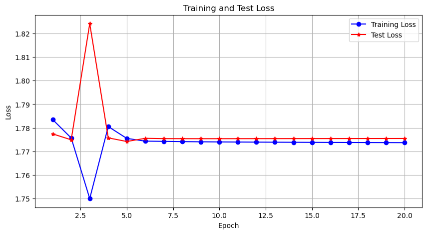

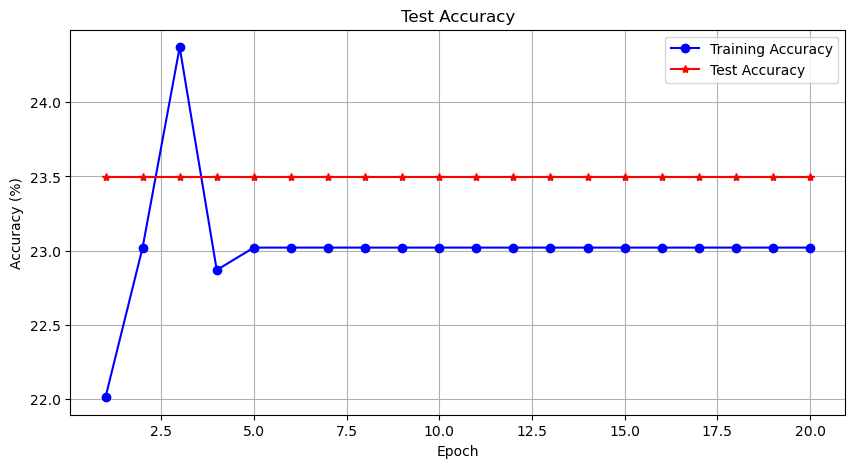

```python
utils.plot_loss_epoch(train_loss_hist, val_loss_hist)
utils.plot_accuracy_epoch(val_acc_hist, train_acc_hist)
```

### LSTMS - The discussion

Unfortunately, training recurrent networks with GRU Cells or LSTM Cells was unsuccesful. We tried many different methods, but in the end none were fixing the issues with models incapability to learn. Here are (some) methods, which we tried:

- different hidden layer sizes
- changing number of LSTM layers
- changing the number of convolutional encoder layers
- tested if it works on the classic nn.LSTM (it doesn't)
- tinkered with hyperparameters, optimizers, schedulers etc.
- tried out different shapes of input matrix to the LSTM network
- Investigated data/data preprocessing (*)

After trying to find a hipothetical bug using these methods, we reached the conclusion, that LSTMs/GRUs are at fault. Maybe it's just hard to train them. What supports our hipothesis, is that ConvLSTM and Resnet3D are learning and achieving satisfying results.

(*) - from our collective experience, if models behaves like that (as if the accuracy/loss gets stuck at a given number and doesn't change at all), it usually is the fault of the data. We spent a lot of time ensuring that the data is in fact correct, besides from the issue described in discussion about the data preprocessing.

```python
#training ConvLSTM
model = ConvLSTMRecurrentClassifier(input_channels=3, hidden_size=16,num_layers=3, num_classes=len(sequencesExtractor.get_classes()),recurrent_module="lstm")
device = torch.device("cuda" if torch.cuda.is_available() else "cpu")
criterion = nn.CrossEntropyLoss()
optimizer = torch.optim.AdamW(model.parameters(), lr=0.001)
scheduler = torch.optim.lr_scheduler.OneCycleLR(optimizer, max_lr=0.01, steps_per_epoch=len(train_dataloader), epochs=num_epochs)
model = model.to(device)
```

```python
train_acc_hist, train_loss_hist, val_acc_hist, val_loss_hist = train_model_v4(num_epochs,
                                                                              model,
                                                                              train_dataloader,
                                                                              val_dataloader,
                                                                              optimizer,
                                                                              criterion,
                                                                              device,
                                                                              "ConvLSTM")
```

```
Epoch 1 Iter 62: loss 1.28501. train accuracy: 27.77777777777778: 100%|██████████| 62/62 [00:37<00:00,  1.66it/s]
```

```
Val accuracy at epoch 0: 39.23%
```

```
Epoch 2 Iter 62: loss 0.83656. train accuracy: 61.111111111111114: 100%|██████████| 62/62 [00:33<00:00,  1.87it/s]
```

```
Val accuracy at epoch 1: 48.03%
```

```
Epoch 3 Iter 62: loss 0.97999. train accuracy: 55.55555555555556: 100%|██████████| 62/62 [00:33<00:00,  1.86it/s]
```

```
Val accuracy at epoch 2: 52.59%
```

```
Epoch 4 Iter 62: loss 0.56490. train accuracy: 77.77777777777779: 100%|██████████| 62/62 [00:33<00:00,  1.85it/s]
```

```
Val accuracy at epoch 3: 63.04%
```

```
Epoch 5 Iter 62: loss 0.54505. train accuracy: 66.66666666666666: 100%|██████████| 62/62 [00:33<00:00,  1.83it/s]
```

```
Val accuracy at epoch 4: 66.82%
```

```
Epoch 6 Iter 62: loss 0.50407. train accuracy: 77.77777777777779: 100%|██████████| 62/62 [00:33<00:00,  1.82it/s]
```

```
Val accuracy at epoch 5: 70.19%
```

```
Epoch 7 Iter 62: loss 0.34142. train accuracy: 83.33333333333334: 100%|██████████| 62/62 [00:34<00:00,  1.81it/s]
```

```
Val accuracy at epoch 6: 72.26%
```

```
Epoch 8 Iter 62: loss 0.25738. train accuracy: 88.88888888888889: 100%|██████████| 62/62 [00:34<00:00,  1.81it/s]
```

```
Val accuracy at epoch 7: 72.93%
```

```
Epoch 9 Iter 62: loss 0.27687. train accuracy: 77.77777777777779: 100%|██████████| 62/62 [00:34<00:00,  1.81it/s]
```

```
Val accuracy at epoch 8: 73.19%
```

```
Epoch 10 Iter 62: loss 0.24981. train accuracy: 88.88888888888889: 100%|██████████| 62/62 [00:34<00:00,  1.80it/s]
```

```
Val accuracy at epoch 9: 74.07%
```

```
Epoch 11 Iter 62: loss 0.19173. train accuracy: 100.0: 100%|██████████| 62/62 [00:34<00:00,  1.81it/s]
```

```
Val accuracy at epoch 10: 77.95%
```

```
Epoch 12 Iter 62: loss 0.18004. train accuracy: 100.0: 100%|██████████| 62/62 [00:34<00:00,  1.81it/s]
```

```
Val accuracy at epoch 11: 79.45%
```

```
Epoch 13 Iter 62: loss 0.19353. train accuracy: 88.88888888888889: 100%|██████████| 62/62 [00:34<00:00,  1.80it/s]
```

```
Val accuracy at epoch 12: 78.99%
```

```
Epoch 14 Iter 62: loss 0.19310. train accuracy: 88.88888888888889: 100%|██████████| 62/62 [00:34<00:00,  1.81it/s]
```

```
Val accuracy at epoch 13: 77.8%
```

```
Epoch 15 Iter 62: loss 0.13843. train accuracy: 100.0: 100%|██████████| 62/62 [00:34<00:00,  1.80it/s]
```

```
Val accuracy at epoch 14: 80.49%
```

```
Epoch 16 Iter 62: loss 0.13082. train accuracy: 100.0: 100%|██████████| 62/62 [00:34<00:00,  1.80it/s]
```

```
Val accuracy at epoch 15: 79.55%
```

```
Epoch 17 Iter 62: loss 0.03512. train accuracy: 100.0: 100%|██████████| 62/62 [00:34<00:00,  1.81it/s]
```

```
Val accuracy at epoch 16: 84.63%
```

```
Epoch 18 Iter 62: loss 0.03355. train accuracy: 100.0: 100%|██████████| 62/62 [00:34<00:00,  1.80it/s]
```

```
Val accuracy at epoch 17: 85.82%
```

```
Epoch 19 Iter 62: loss 0.00887. train accuracy: 100.0: 100%|██████████| 62/62 [00:34<00:00,  1.80it/s]
```

```
Val accuracy at epoch 18: 87.11%
```

```
Epoch 20 Iter 62: loss 0.00594. train accuracy: 100.0: 100%|██████████| 62/62 [00:34<00:00,  1.80it/s]
```

```
Val accuracy at epoch 19: 88.15%
```

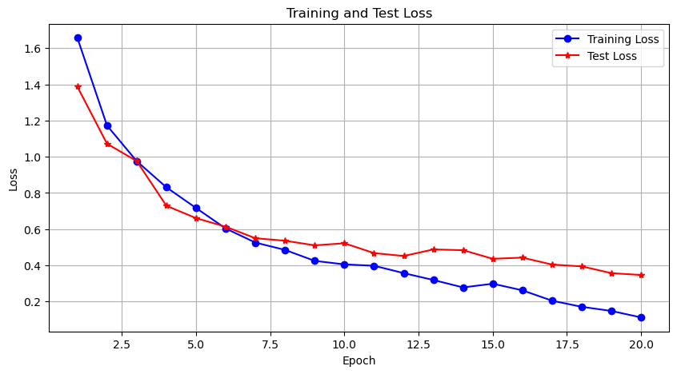

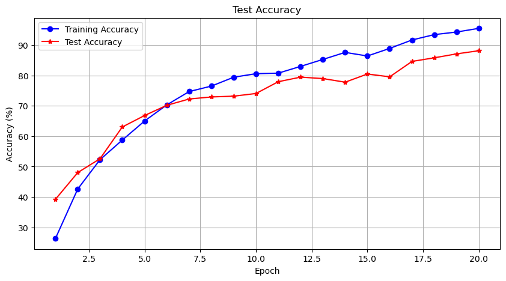

```python
utils.plot_loss_epoch(train_loss_hist, val_loss_hist)
utils.plot_accuracy_epoch(val_acc_hist, train_acc_hist)
```

The ConvLSTM performed very well. After 20 epochs we achieve 88% accuracy. This is intuitive. Due to the spacial features used in our recurrent blocks, the network appears to be superior in differentiating sequential visual data. We also note, that now our accuracy and loss curves look more ordinary now. Looking at the loss curves we observe however that our network has not entirely converged yet. Some more epochs would have probably ameliorated our performance. Additionally, we also begin to see that our network starts to overfit at the later epochs. This leads us to believe that some transforms or dropout might be helpful in mitigating overfitting, especially when adding more epochs.

## Bonus task

```python
def conv3x3x3(in_planes, out_planes, stride=1):
    return nn.Conv3d(
        in_planes,
        out_planes,
        kernel_size=3,
        stride=stride,
        padding=1,
        bias=False)

class BasicBlock(nn.Module):
    expansion = 1

    def __init__(self, inplanes, planes, stride=1, downsample=None):
        super(BasicBlock, self).__init__()
        self.conv1 = conv3x3x3(inplanes, planes, stride)
        self.bn1 = nn.BatchNorm3d(planes)
        self.relu = nn.ReLU(inplace=True)
        self.conv2 = conv3x3x3(planes, planes)
        self.bn2 = nn.BatchNorm3d(planes)
        self.downsample = downsample
        self.stride = stride

    def forward(self, x):
        residual = x

        out = self.conv1(x)
        out = self.bn1(out)
        out = self.relu(out)

        out = self.conv2(out)
        out = self.bn2(out)

        if self.downsample is not None:
            residual = self.downsample(x)

        out += residual
        out = self.relu(out)

        return out

class ResNet(nn.Module):

    def __init__(self, block, layers, num_classes=1000):
        self.inplanes = 64
        super(ResNet, self).__init__()
        self.conv1 = nn.Conv3d(
            3,
            64,
            kernel_size=7,
            stride=(2, 2, 2),
            padding=(3, 3, 3),
            bias=False)
        self.bn1 = nn.BatchNorm3d(64)
        self.relu = nn.ReLU(inplace=True)
        self.maxpool = nn.MaxPool3d(kernel_size=(3, 3, 3), stride=2, padding=1)
        self.layer1 = self._make_layer(block, 64, layers[0])
        self.layer2 = self._make_layer(block, 128, layers[1], stride=2)
        self.layer3 = self._make_layer(block, 256, layers[2], stride=2)
        self.layer4 = self._make_layer(block, 512, layers[3], stride=2)
        self.avgpool = nn.AdaptiveAvgPool3d((1, 1, 1))
        self.fc = nn.Linear(512 * block.expansion, num_classes)

        for m in self.modules():
            if isinstance(m, nn.Conv3d):
                nn.init.kaiming_normal_(m.weight, mode='fan_out', nonlinearity='relu')
            elif isinstance(m, nn.BatchNorm3d):
                nn.init.constant_(m.weight, 1)
                nn.init.constant_(m.bias, 0)

    def _make_layer(self, block, planes, blocks, stride=1):
        downsample = None
        if stride != 1 or self.inplanes != planes * block.expansion:
            downsample = nn.Sequential(
                nn.Conv3d(
                    self.inplanes,
                    planes * block.expansion,
                    kernel_size=1,
                    stride=stride,
                    bias=False), nn.BatchNorm3d(planes * block.expansion))

        layers = []
        layers.append(block(self.inplanes, planes, stride, downsample))
        self.inplanes = planes * block.expansion
        for i in range(1, blocks):
            layers.append(block(self.inplanes, planes))

        return nn.Sequential(*layers)

    def forward(self, x):
        x = self.conv1(x)
        x = self.bn1(x)
        x = self.relu(x)
        x = self.maxpool(x)

        x = self.layer1(x)
        x = self.layer2(x)
        x = self.layer3(x)
        x = self.layer4(x)

        x = self.avgpool(x)

        x = x.view(x.size(0), -1)
        x = self.fc(x)

        return x
```

```python
model_resnet = ResNet(BasicBlock, [2, 2, 2, 2], num_classes = len(sequencesExtractor.get_classes()))
```

```python
print(len(sequencesExtractor.get_classes()))
```

```
6
```

```python
criterion = nn.CrossEntropyLoss()
optimizer = torch.optim.SGD(model_resnet.parameters(), lr=0.001, momentum=0.9)

# Device configuration
device = torch.device('cuda' if torch.cuda.is_available() else 'cpu')
model_resnet = model_resnet.to(device)
```

```python
model_parameters = filter(lambda p: p.requires_grad, model_resnet.parameters())
params = sum([np.prod(p.size()) for p in model_parameters])
print(params)
```

```
33206982
```

```python
train_acc_hist, train_loss_hist, val_acc_hist, val_loss_hist = train_model_v4(num_epochs = num_epochs_resnet,
                                                                              chosen_model = model_resnet,
                                                                              train_dataloader = train_dataloader,
                                                                              val_dataloader = val_dataloader,
                                                                              optimizer = optimizer,
                                                                              criterion = criterion,
                                                                              device = device,
                                                                              model_type = "resnet")
```

```
Epoch 1 Iter 31: loss 1.13627. train accuracy: 48.78048780487805: 100%|██████████████████████████████| 31/31 [00:06<00:00,  4.65it/s]
```

```
Val accuracy at epoch 0: 48.91%
```

```
Epoch 2 Iter 31: loss 0.82751. train accuracy: 62.19512195121951: 100%|██████████████████████████████| 31/31 [00:07<00:00,  4.37it/s]
```

```
Val accuracy at epoch 1: 60.09%
```

```
Epoch 3 Iter 31: loss 0.68891. train accuracy: 70.73170731707317: 100%|██████████████████████████████| 31/31 [00:07<00:00,  4.32it/s]
```

```
Val accuracy at epoch 2: 66.05%
```

```
Epoch 4 Iter 31: loss 0.58911. train accuracy: 81.70731707317073: 100%|██████████████████████████████| 31/31 [00:06<00:00,  4.45it/s]
```

```
Val accuracy at epoch 3: 66.2%
```

```
Epoch 5 Iter 31: loss 0.53198. train accuracy: 81.70731707317073: 100%|██████████████████████████████| 31/31 [00:06<00:00,  4.61it/s]
```

```
Val accuracy at epoch 4: 66.77%
```

```
Epoch 6 Iter 31: loss 0.50569. train accuracy: 79.26829268292683: 100%|██████████████████████████████| 31/31 [00:06<00:00,  4.70it/s]
```

```
Val accuracy at epoch 5: 68.69%
```

```
Epoch 7 Iter 31: loss 0.43474. train accuracy: 81.70731707317073: 100%|██████████████████████████████| 31/31 [00:06<00:00,  4.81it/s]
```

```
Val accuracy at epoch 6: 69.98%
```

```
Epoch 8 Iter 31: loss 0.42335. train accuracy: 81.70731707317073: 100%|██████████████████████████████| 31/31 [00:06<00:00,  4.52it/s]
```

```
Val accuracy at epoch 7: 74.48%
```

```
Epoch 9 Iter 31: loss 0.41361. train accuracy: 82.92682926829268: 100%|██████████████████████████████| 31/31 [00:07<00:00,  4.36it/s]
```

```
Val accuracy at epoch 8: 74.43%
```

```
Epoch 10 Iter 31: loss 0.36303. train accuracy: 85.36585365853658: 100%|█████████████████████████████| 31/31 [00:07<00:00,  4.00it/s]
```

```
Val accuracy at epoch 9: 77.23%
```

```
Epoch 11 Iter 31: loss 0.26729. train accuracy: 92.6829268292683: 100%|██████████████████████████████| 31/31 [00:06<00:00,  4.92it/s]
```

```
Val accuracy at epoch 10: 78.67%
```

```
Epoch 12 Iter 31: loss 0.32223. train accuracy: 87.8048780487805: 100%|██████████████████████████████| 31/31 [00:07<00:00,  4.41it/s]
```

```
Val accuracy at epoch 11: 75.78%
```

```
Epoch 13 Iter 31: loss 0.29917. train accuracy: 86.58536585365853: 100%|█████████████████████████████| 31/31 [00:06<00:00,  4.49it/s]
```

```
Val accuracy at epoch 12: 74.02%
```

```
Epoch 14 Iter 31: loss 0.28723. train accuracy: 89.02439024390245: 100%|█████████████████████████████| 31/31 [00:07<00:00,  4.39it/s]
```

```
Val accuracy at epoch 13: 76.55%
```

```
Epoch 15 Iter 31: loss 0.21181. train accuracy: 93.90243902439023: 100%|█████████████████████████████| 31/31 [00:06<00:00,  4.47it/s]
```

```
Val accuracy at epoch 14: 77.17%
```

```
Epoch 16 Iter 31: loss 0.28975. train accuracy: 91.46341463414635: 100%|█████████████████████████████| 31/31 [00:06<00:00,  4.62it/s]
```

```
Val accuracy at epoch 15: 74.33%
```

```
Epoch 17 Iter 31: loss 0.30002. train accuracy: 90.2439024390244: 100%|██████████████████████████████| 31/31 [00:07<00:00,  4.41it/s]
```

```
Val accuracy at epoch 16: 75.52%
```

```
Epoch 18 Iter 31: loss 0.20562. train accuracy: 95.1219512195122: 100%|██████████████████████████████| 31/31 [00:06<00:00,  4.54it/s]
```

```
Val accuracy at epoch 17: 78.11%
```

```
Epoch 19 Iter 31: loss 0.21962. train accuracy: 92.6829268292683: 100%|██████████████████████████████| 31/31 [00:07<00:00,  4.41it/s]
```

```
Val accuracy at epoch 18: 78.62%
```

```
Epoch 20 Iter 31: loss 0.16772. train accuracy: 96.34146341463415: 100%|█████████████████████████████| 31/31 [00:06<00:00,  4.50it/s]
```

```
Val accuracy at epoch 19: 79.09%
```

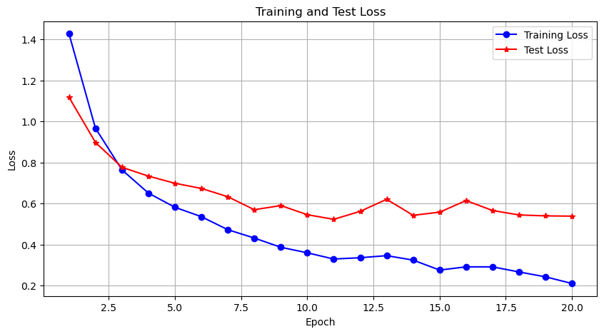

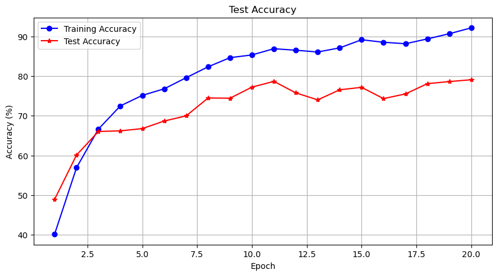

```python
utils.plot_loss_epoch(train_loss_hist, val_loss_hist)
utils.plot_accuracy_epoch(val_acc_hist, train_acc_hist)
```

### Comment

Resnet achieves satisfactory results, it gets about ~80% accuracy depending on a run. It is worth mentioning that the model gains around 10% accuracy if we exclude "walking", "jogging" and "running" for a known reason. We also tested the model with incresed number of parameters, but that didn't change anything. It turnes out that ConvLSTM is the best performing model.